# Homework 8

Marcelo Santos Carielo

03/03/2021

## Atividade: Análise de Dados PNAD COVID-19

1. Aprendemos, através de vários exemplos, como podemos explorar o conjunto de dados da PNAD COVID-19 disponibilizado pelo IBGE. Agora é a sua vez. Nessa atividade, você deverá usar o mesmo banco de dados para avaliar questões distintas das que foram propostas na aula. Busque analisar outras variáveis, fazer uma análise por região, estado, grupo de municı́pios, etc. Você também pode melhorar a apresentação dos gráficos disponibilizados na aula. As possibilidades são imensas e você deverá explorá-las. Coloque em prática todas as ferramentas que aprendemos anteriormente. Quanto maior o número de elementos utilizados, maior será a sua nota. Utilize toda a sua criatividade e conhecimento. Bom trabalho!

Resp:

Nesta atividade utilizaremos o conjunto de dados da PNAD COVID-19, disponibilizado pelo IBGE em novembro de 2020.

### Descrição da base de dados

Iniciamos carregando a base de dados (.csv) e o dicionário (.xlxs) que a descreve.

```r
library(tidyverse)
```

```r
library(ggplot2)
library(readxl)
library(readr)
library(srvyr) # trabalha com amostras complexas
#?srvyr

db_dict <- read_excel("Dicionario_PNAD_COVID_112020.xls",
                      sheet = "dicionário pnad covid")
```

```
## * `` -> ...2
## * `` -> ...3
## * `` -> ...4
## * `` -> ...5
## * `` -> ...6
```

```r
db_pnad <- read.csv("PNAD_COVID_112020.csv") # obs: ~115MB

head(db_pnad)
```

```
##    Ano UF CAPITAL RM_RIDE V1008 V1012 V1013 V1016 Estrato       UPA V1022 V1023
## 1 2020 11      11      NA     1     4    11     7 1110011 110015970     1     1
## 2 2020 11      11      NA     1     4    11     7 1110011 110015970     1     1
## 3 2020 11      11      NA     1     4    11     7 1110011 110015970     1     1
## 4 2020 11      11      NA     1     4    11     7 1110011 110015970     1     1
## 5 2020 11      11      NA     2     1    11     7 1110011 110015970     1     1
## 6 2020 11      11      NA     3     2    11     7 1110011 110015970     1     1
##    V1030    V1031    V1032 posest A001 A001A A001B1 A001B2 A001B3 A002 A003
## 1 152902 101.0117 117.4637   1114    1     1      5      8   1984   36    1
## 2 150835 101.0117 125.7512   1124    2     2     18      8   1990   30    2
## 3 144737 101.0117 131.3610   1112    3     4     25     12   2006   13    1
## 4 144737 101.0117 131.3610   1112    4     4     24      8   2009   11    1
## 5  92377 101.0117 100.7335   1126    1     1     18      5   1963   57    2
## 6  92377 101.0117 100.7335   1126    1     1     25     12   1961   58    2
##   A004 A005 A006 A006A A006B A007 A007A A008 A009 B0011 B0012 B0013 B0014 B0015
```

[output cut: 69 more lines]

Vejamos a estrutura desta base de dados:

```r
dim(db_pnad)
```

```
## [1] 381438    148
```

```r
str(db_pnad)
```

```
## 'data.frame':    381438 obs. of  148 variables:
##  $ Ano    : int  2020 2020 2020 2020 2020 2020 2020 2020 2020 2020 ...
##  $ UF     : int  11 11 11 11 11 11 11 11 11 11 ...
##  $ CAPITAL: int  11 11 11 11 11 11 11 11 11 11 ...
##  $ RM_RIDE: int  NA NA NA NA NA NA NA NA NA NA ...
##  $ V1008  : int  1 1 1 1 2 3 4 4 4 4 ...
##  $ V1012  : int  4 4 4 4 1 2 4 4 4 4 ...
##  $ V1013  : int  11 11 11 11 11 11 11 11 11 11 ...
##  $ V1016  : int  7 7 7 7 7 7 7 7 7 7 ...
##  $ Estrato: int  1110011 1110011 1110011 1110011 1110011 1110011 1110011 1110011 1110011 1110011 ...
##  $ UPA    : int  110015970 110015970 110015970 110015970 110015970 110015970 110015970 110015970 110015970 110015970 ...
##  $ V1022  : int  1 1 1 1 1 1 1 1 1 1 ...
##  $ V1023  : int  1 1 1 1 1 1 1 1 1 1 ...
##  $ V1030  : int  152902 150835 144737 144737 92377 92377 123734 138562 144737 134209 ...
##  $ V1031  : num  101 101 101 101 101 ...
```

[output cut: 86 more lines]

## Selecionando algumas informações de interesse

```r
# Sobre srvyr:
# "There are three stages to using srvyr functions, creating a survey object, manipulating the data, and calculating survey statistics."
#?as_survey_design
#?as_survey_rep
#?as_survey_twophase


# coloca pesos e filtra pelo município de belo horizonte/mg
db_pesos <- db_pnad %>%
  as_survey_design(ids=UPA, strata=Estrato, weights=V1032, nest=TRUE) %>%
  filter(UF == "31")

db_pesos$variables
```

```
## # A tibble: 34,339 x 148
##      Ano    UF CAPITAL RM_RIDE V1008 V1012 V1013 V1016 Estrato    UPA V1022
##    <int> <int>   <int>   <int> <int> <int> <int> <int>   <int>  <int> <int>
##  1  2020    31      31      31     1     3    11     7 3110111 3.10e8     1
##  2  2020    31      31      31     1     3    11     7 3110111 3.10e8     1
##  3  2020    31      31      31     1     3    11     7 3110111 3.10e8     1
##  4  2020    31      31      31     2     1    11     7 3110111 3.10e8     1
##  5  2020    31      31      31     5     2    11     7 3110111 3.10e8     1
##  6  2020    31      31      31     5     2    11     7 3110111 3.10e8     1
##  7  2020    31      31      31     6     4    11     7 3110111 3.10e8     1
##  8  2020    31      31      31     6     4    11     7 3110111 3.10e8     1
##  9  2020    31      31      31     6     4    11     7 3110111 3.10e8     1
## 10  2020    31      31      31     6     4    11     7 3110111 3.10e8     1
## # … with 34,329 more rows, and 137 more variables: V1023 <int>, V1030 <int>,
## #   V1031 <dbl>, V1032 <dbl>, posest <int>, A001 <int>, A001A <int>,
## #   A001B1 <int>, A001B2 <int>, A001B3 <int>, A002 <int>, A003 <int>,
## #   A004 <int>, A005 <int>, A006 <int>, A006A <int>, A006B <int>, A007 <int>,
## #   A007A <int>, A008 <int>, A009 <int>, B0011 <int>, B0012 <int>, B0013 <int>,
## #   B0014 <int>, B0015 <int>, B0016 <int>, B0017 <int>, B0018 <int>,
## #   B0019 <int>, B00110 <int>, B00111 <int>, B00112 <int>, B00113 <int>,
## #   B002 <int>, B0031 <int>, B0032 <int>, B0033 <int>, B0034 <int>,
## #   B0035 <int>, B0036 <int>, B0037 <int>, B0041 <int>, B0042 <int>,
## #   B0043 <int>, B0044 <int>, B0045 <int>, B0046 <int>, B005 <int>, B006 <int>,
## #   B007 <int>, B008 <int>, B009A <int>, B009B <int>, B009C <int>, B009D <int>,
## #   B009E <int>, B009F <int>, B0101 <int>, B0102 <int>, B0103 <int>,
## #   B0104 <int>, B0105 <int>, B0106 <int>, B011 <int>, C001 <int>, C002 <int>,
## #   C003 <int>, C004 <int>, C005 <int>, C0051 <int>, C0052 <int>, C0053 <int>,
## #   C006 <int>, C007 <int>, C007A <int>, C007B <int>, C007C <int>, C007D <int>,
## #   C007E <int>, C007E1 <int>, C007E2 <int>, C007F <int>, C008 <int>,
## #   C009 <int>, C009A <int>, C010 <int>, C0101 <int>, C01011 <int>,
## #   C01012 <int>, C0102 <int>, C01021 <int>, C01022 <int>, C0103 <int>,
## #   C0104 <int>, C011A <int>, C011A1 <int>, C011A11 <int>, C011A12 <int>,
## #   C011A2 <int>, …
```

```r
#summary(db_pesos$variables$CAPITAL)
```

```r
pnad_pesos <- db_pesos %>%
  mutate(one = 1,
         Sexo = ifelse(A003 == 1, "Homem", "Mulher"),
         Idade = case_when(
           A002 %in% 15:24 ~ "15-24",
           A002 %in% 25:34 ~ "25-34",
           A002 %in% 35:49 ~ "35-49",
           A002 %in% 50:64 ~ "50-64",
           A002 > 64 ~ "65+"),
         Cor = case_when(
           A004 == 1 ~ "Branca",
           A004 == 2 ~ "Preta",
           A004 == 4 ~ "Parda"),
         Escolaridade = factor(case_when(  ##usando factor conseguimos ordenar
           A005 %in% 1:2 ~ "Sem Instrução ou Fundamental Incompleto",
           A005 %in% 3:4 ~ "Fundamental completo ou Médio Incompleto",
           A005 %in% 5:6 ~ "Médio completo ou Superior Incompleto",
           A005 == 7 ~ "Superior completo",
           A005 == 8 ~ "Pós-graduação"),
           levels = c("Sem Instrução ou Fundamental Incompleto",
                      "Fundamental completo ou Médio Incompleto",
                      "Médio completo ou Superior Incompleto",
                      "Superior completo",
                      "Pós-graduação")),
         Tipo_emprego = factor(case_when(
           C007 == 1 ~ "Trabalhador doméstico (empregado doméstico, cuidados, babá)",
           C007 == 2 ~ "Militar",
           C007 == 3 ~ "Policial ou Bombeiro",
           C007 == 4 ~ "Setor privado",
           C007 == 5 ~ "Setor público",
           C007 == 6 ~ "Empregador",
           C007 == 7 ~ "Autônomo (Conta própria)"),
           levels = c( "Trabalhador doméstico (empregado doméstico, cuidados, babá)",
               "Militar",
               "Policial ou Bombeiro",
               "Setor privado",
               "Setor público",
               "Empregador",
               "Autônomo (Conta própria)")),
         Faixa_salario = factor(case_when(
           C01012 <= 1044 ~ "Menos de um salário mínimo",
           C01012 %in% c(1045:2090) ~ "Entre 1 e 2",
           C01012 %in% c(2091:3135) ~ "Entre 2 e 3",
           C01012 %in% c(3136:4180) ~ "Entre 3 e 4",
           C01012 %in% c(4181:5225) ~ "Entre 4 e 5",
           C01012 >= 5226 ~ "Mais de 5"),
           levels = c("Menos de um salário mínimo",
               "Entre 1 e 2",
               "Entre 2 e 3",
               "Entre 3 e 4",
               "Entre 4 e 5",
               "Mais de 5")),
         domicilio_situacao = factor(case_when(
           F001 == 1 ~ "Próprio - já pago",
           F001 == 2 ~ "Próprio - ainda pagando" ,
           F001 == 3 ~ "Alugado",
           F001 %in% 4:6 ~ "Cedido (Por empregador, Familiar ou outro)"),
           levels = c("Próprio - já pago",
                      "Próprio - ainda pagando",
                      "Alugado",
                      "Cedido (Por empregador, Familiar ou outro)")),
         home_office = ifelse(C013 == 1, "Home Office", "Presencial"),
         auxilio_emergencial = ifelse(D0051 == 1, "Auxílio", "Sem auxílio"),
         fez_emprestimo = case_when(
           E001 == 1 ~ "Sim, e pelo menos um morador conseguiu",
           E001 == 2 ~ "Sim, mas nenhum morador conseguiu ",
           E001 == 3 ~ "Não solicitou"),
         teve_covid = ifelse(B009B == 1, "Sim", "Não"),
)

names(pnad_pesos)
```

```
## [1] "cluster"    "strata"     "has.strata" "prob"       "allprob"
## [6] "call"       "variables"  "fpc"        "pps"
```

### Análise sobre os empréstimos realizados durante a pandemia

A pergunta realizada nas pesquisas, por domicílio, foi: “Durante o período da pandemia alguém deste domicílio solicitou algum empréstimo?” (código da variável E001, segundo o dicionário do PNAD COVID). As respostas para esta pergunta se dividiram em: “Sim, e pelo menos um morador conseguiu”; “Sim, mas nenhum morador conseguiu” e “Não”. Para nossos interesses, dividimos essas respostas em “Sim” (para o primeiro caso, quando de fato o empréstimo se efetivou) ou “Não”, caso contrário.

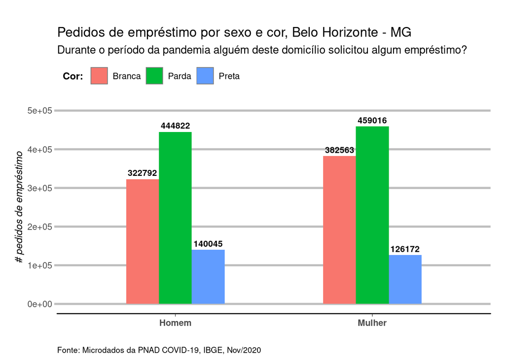

```r
#names(pnad_pesos$variables)
#?survey_total

# separa um conjunto de dados para fazer o gráfico desejado: empréstimo por sexo, e cor:
sexo_cor <- pnad_pesos %>%
  group_by(Sexo, Cor) %>%
  summarise(emprestimo=survey_total(E001 == 1, na.rm = TRUE)) %>% #pediu empréstimo?
  mutate(fez_emprestimo=emprestimo) %>%
  drop_na()
#head(sexo_cor)

# gera gráfico
subtitle_grafico <- "Durante o período da pandemia alguém deste domicílio solicitou algum empréstimo?"

grafico1 <- ggplot(data=sexo_cor,
                  aes(x=Sexo, y=fez_emprestimo, fill=Cor))+
  geom_bar(position="dodge", stat="identity", width=0.5) +
  scale_y_continuous(limits = c(-100, 0.5e+06)) +
  geom_text(aes(label=sprintf("%.0f", fez_emprestimo)),
            size=3, position=position_dodge(width=0.5),
            vjust=-0.5, hjust=0.5, color = 'black', fontface='bold') +
  labs(title="Pedidos de empréstimo por sexo e cor, Belo Horizonte - MG",
       subtitle=subtitle_grafico,
       x="", y="# pedidos de empréstimo", tag="  ",
       fill="Cor: ",
       caption="Fonte: Microdados da PNAD COVID-19, IBGE, Nov/2020") +
  theme_dark() +
  guides(col=guide_legend(nrow=1))+
  theme(axis.title = element_text(size=10, face="italic"),
        plot.caption = element_text(hjust= 0.0, size=8, vjust=0.0),
        axis.line.y = element_blank(),
        axis.line.x = element_line(lineend="round"),
        axis.ticks.length = unit(0.2, "lines"),
        axis.ticks.y = element_line(colour="gray", size=1),
        legend.background = element_rect(fill="white", colour=NA),
        legend.position = 'top',
        legend.justification = 'left',
        legend.direction = 'horizontal',
        legend.title = element_text(size=rel(0.9), face="bold", vjust=0.5),
        panel.background = element_blank(),
        axis.text.x = element_text(angle=0, vjust=0.5, face="bold"),
        panel.border = element_blank(),
        panel.grid.minor = element_blank(),
        panel.grid.major.y = element_line(colour="gray", size=1),
        panel.grid.major.x = element_blank(),
        plot.margin = unit(c(1, 1, 0.5, 0.5), "lines"),
        strip.background = element_rect(fill="grey90", colour="grey50"),
        strip.text.y = element_text(size=rel(0.8), angle=-90)
  )

grafico1
```

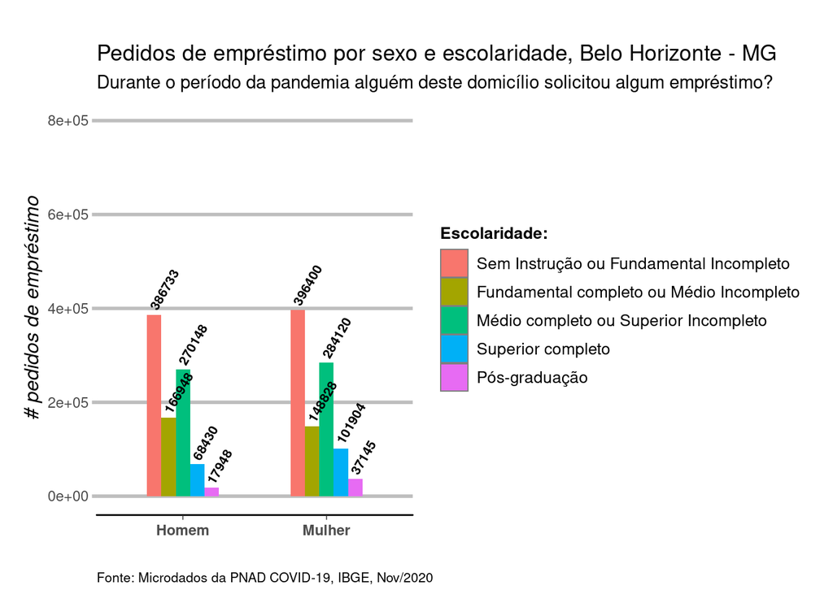

```r
#names(pnad_pesos$variables)
#?survey_total

# separa um conjunto de dados para fazer o gráfico desejado: empresitmo por sexo e escolaridade:
sexo_escolaridade <- pnad_pesos %>%
  group_by(Sexo, Escolaridade) %>%
  summarise(emprestimo=survey_total(E001 == 1, na.rm = TRUE)) %>% #pediu empréstimo?
  mutate(fez_emprestimo=emprestimo) %>%
  drop_na()
#head(sexo_cor)

# gera gráfico
subtitle_grafico <- "Durante o período da pandemia alguém deste domicílio solicitou algum empréstimo?"

grafico2 <- ggplot(data=sexo_escolaridade,
                   aes(x=Sexo, y=fez_emprestimo, fill=Escolaridade))+
  geom_bar(position="dodge", stat="identity", width=0.5) +
  scale_y_continuous(limits = c(-100, 0.8e+06)) +
  geom_text(aes(label=sprintf("%.0f", fez_emprestimo)),
            size=2.8, position=position_dodge(width=0.5),
            vjust=0.1, hjust=-0.1, color = 'black', fontface='bold', angle=60) +
  labs(title="Pedidos de empréstimo por sexo e escolaridade, Belo Horizonte - MG",
       subtitle=subtitle_grafico,
       x="", y="# pedidos de empréstimo", tag="  ",
       fill="Escolaridade: ",
       caption="Fonte: Microdados da PNAD COVID-19, IBGE, Nov/2020") +
  theme_dark() +
  guides(col=guide_legend(nrow=1))+
  theme(axis.title = element_text(size=12, face="italic"),
        plot.caption = element_text(hjust= 0.0, size=8, vjust=0.0),
        axis.line.y = element_blank(),
        axis.line.x = element_line(lineend="round"),
        axis.ticks.length = unit(0.2, "lines"),
        axis.ticks.y = element_line(colour="gray", size=1),
        legend.background = element_rect(fill="white", colour=NA),
        legend.position = 'right',
        legend.justification = 'center',
        legend.direction = 'vertical',
        legend.text = element_text(size=rel(0.9), vjust=0.5),
        legend.title = element_text(size=rel(0.9), vjust=0.5, face="bold"),
        panel.background = element_blank(),
        axis.text.x = element_text(angle=0, vjust=0.5, face="bold"),
        panel.border = element_blank(),
        panel.grid.minor = element_blank(),
        panel.grid.major.y = element_line(colour="gray", size=1),
        panel.grid.major.x = element_blank(),
        plot.margin = unit(c(1, 1, 0.5, 0.5), "lines"),
        #plot.title = element_text(size=rel(0.9)),
        strip.background = element_rect(fill="grey90", colour="grey50"),
        strip.text.y = element_text(size=rel(0.7), angle=-90)
  )

grafico2
```

Dentre os que pediram empréstimo, para ambos os sexos, os que possuem grau de escolaridade ‘Sem instrução ou Fundamental’ ou ‘Médio completo e Superior Incompleto’ são os que tiveram mais participação. O gráfico ilustra esse aspecto, além de mostrar que aqueles com ‘Pós-graduação’ foram os que menos pediram empréstimo ao durante a pandemia.

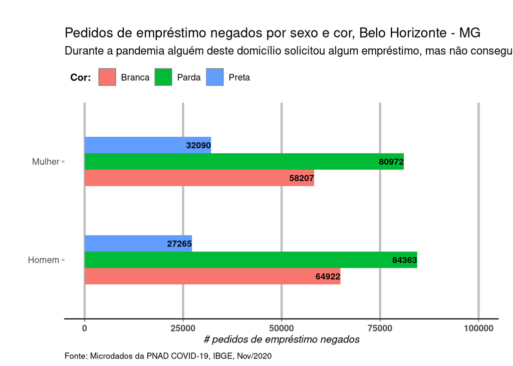

```r
# separa um conjunto de dados para fazer o gráfico desejado: solicitou empréstimo mas não conseguiu por sexo e cor em bh:
sexo_cor <- pnad_pesos %>%
  group_by(Sexo, Cor) %>%
  summarise(emprestimo=survey_total(E001 == 2, na.rm = TRUE)) %>% #pediu empréstimo e não conseguiu?
  mutate(nao_conseguiu_emprestimo=emprestimo) %>%
  drop_na()
#head(sexo_cor)

# gera gráfico
subtitle_grafico <- "Durante a pandemia alguém deste domicílio solicitou algum empréstimo, mas não conseguiu?"

grafico3 <- ggplot(data=sexo_cor,
                  aes(x=Sexo, y=nao_conseguiu_emprestimo, fill=Cor))+
  geom_bar(position="dodge", stat="identity", width=0.5) +
  scale_y_continuous(limits = c(-100, 1e+05)) +
  geom_text(aes(label=sprintf("%.0f", nao_conseguiu_emprestimo)),
            size=3, position=position_dodge(width=0.5),
            vjust=0.5, hjust=1.0, color = 'black', fontface='bold') +
  labs(title="Pedidos de empréstimo negados por sexo e cor, Belo Horizonte - MG",
       subtitle=subtitle_grafico,
       x="", y="# pedidos de empréstimo negados", tag="  ",
       fill="Cor: ",
       caption="Fonte: Microdados da PNAD COVID-19, IBGE, Nov/2020") +
  theme_dark() +
  guides(col=guide_legend(nrow=1))+
  theme(axis.title = element_text(size=10, face="italic"),
        plot.caption = element_text(hjust= 0.0, size=8, vjust=0.0),
        axis.line.y = element_blank(),
        axis.line.x = element_line(lineend="round"),
        axis.ticks.length = unit(0.2, "lines"),
        axis.ticks.y = element_line(colour="gray", size=1),
        legend.background = element_rect(fill="white", colour=NA),
        legend.position = 'top',
        legend.justification = 'left',
        legend.direction = 'horizontal',
        legend.title = element_text(size=rel(0.9), face="bold", vjust=0.5),
        panel.background = element_blank(),
        axis.text.x = element_text(angle=0, vjust=0.5, face="bold"),
        panel.border = element_blank(),
        panel.grid.minor = element_blank(),
        panel.grid.major.x = element_line(colour="gray", size=1),
        panel.grid.major.y = element_blank(),
        plot.margin = unit(c(1, 1, 0.5, 0.5), "lines"),
        strip.background = element_rect(fill="grey90", colour="grey50"),
        strip.text.y = element_text(size=rel(0.8), angle=-90)
  ) +
  coord_flip()

grafico3
```

Os gráficos mostram que cor, sexo e nível de escolaridade dos indivíduos podem influenciar no quesito “empréstimos durante a pandemia”.

### Informações sobre COVID-19

Restringindo a questão “Durante a pandemia alguém do domicílio pediu empréstimo, mas não conseguiu?” aos que testaram positivo para COVID-19, a distrubuição dos dados fica como o gráfico abaixo.

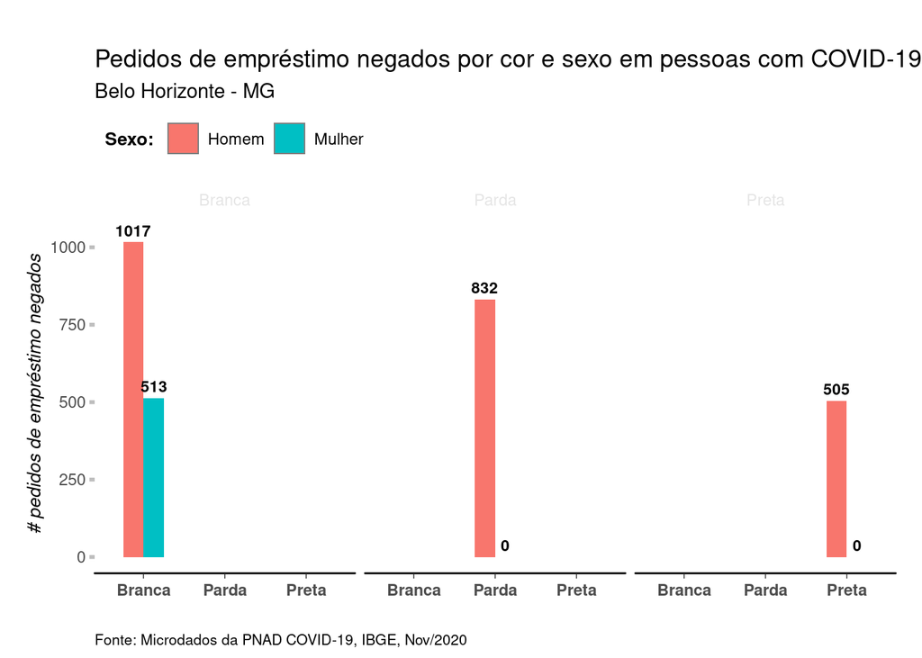

```r
# separa um conjunto de dados para fazer o gráfico desejado: solicitou empréstimo mas não conseguiu por sexo e COVID-19 em bh:
cor_sexo_covid <- pnad_pesos %>%
  filter(B009B == 1, na.rm = TRUE) %>%
  group_by(Sexo, Cor) %>%
  summarise(emprestimo=survey_total(E001 == 2, na.rm = TRUE)) %>% # pediu empréstimo e não conseguiu?
  mutate(nao_conseguiu_emprestimo=emprestimo) %>%
  drop_na()
#head(cor_covid)

grafico4 <- ggplot(data=cor_sexo_covid,
                  aes(x=Cor, y=nao_conseguiu_emprestimo, fill=Sexo))+
  geom_bar(position="dodge", stat="identity", width=0.5) +
  scale_y_continuous(limits = c(0, 1.05e+03)) +
  geom_text(aes(label=sprintf("%.0f", nao_conseguiu_emprestimo)),
            size=3, position=position_dodge(width=0.5),
            vjust=-0.5, hjust=0.5, color = 'black', fontface='bold') +
  facet_wrap(~Cor) +
  labs(title='Pedidos de empréstimo negados por cor e sexo em pessoas com COVID-19',
       subtitle='Belo Horizonte - MG',
       x="", y="# pedidos de empréstimo negados", tag="  ",
       fill="Sexo: ",
       caption="Fonte: Microdados da PNAD COVID-19, IBGE, Nov/2020") +
  theme_dark() +
  guides(col=guide_legend(nrow=1))+
  theme(axis.title = element_text(size=10, face="italic"),
        plot.caption = element_text(hjust= 0.0, size=8, vjust=0.0),
        axis.line.y = element_blank(),
        axis.line.x = element_line(lineend="round"),
        axis.ticks.length = unit(0.2, "lines"),
        axis.ticks.y = element_line(colour="gray", size=1),
        legend.background = element_rect(fill="white", colour=NA),
        legend.position = 'top',
        legend.justification = 'left',
        legend.direction = 'horizontal',
        legend.title = element_text(size=rel(0.9), face="bold", vjust=0.5),
        panel.background = element_blank(),
        axis.text.x = element_text(angle=0, vjust=0.5, face="bold"),
        panel.border = element_blank(),
        panel.grid.minor = element_blank(),
        panel.grid.major.x = element_blank(),
        panel.grid.major.y = element_blank(),
        plot.margin = unit(c(1, 1, 0.5, 0.5), "lines"),
        strip.background = element_blank(),
        strip.text.y = element_text(size=rel(0.8), angle=-90)
  )

grafico4
```

A seguir vemos a relação entre empréstimos solicitados e o tipo de emprego dos entrevistados pelo PNAD.

```r
# tipo de emprego e empréstimos
home_emprego_emprestimo <- pnad_pesos %>%
    filter(E001 == 1) %>%
  group_by(Tipo_emprego) %>%
  summarise(esta_em_home_office = survey_total(C013 == 1, na.rm=TRUE)) %>%
  mutate(home_office_emprestimo = esta_em_home_office) %>%
  drop_na()
head(home_emprego_emprestimo)
```

```
## # A tibble: 6 x 4
##   Tipo_emprego             esta_em_home_off… esta_em_home_off… home_office_empr…
##   <fct>                                <dbl>             <dbl>             <dbl>
## 1 Trabalhador doméstico (…                0                 0                 0
## 2 Militar                                 0                 0                 0
## 3 Policial ou Bombeiro                    0                 0                 0
## 4 Setor privado                       16361.             3411.            16361.
## 5 Setor público                       30902.             5433.            30902.
## 6 Empregador                           3150.             1877.             3150.
```

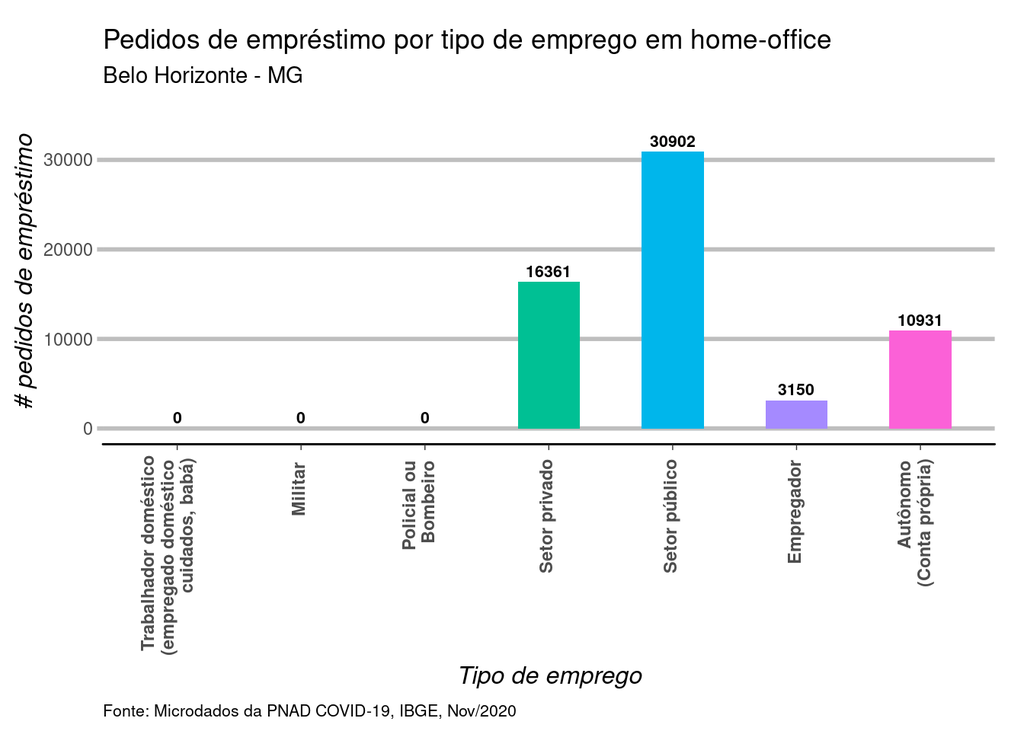

```r
# eixo x ordenado
legenda_trabalhos <- c("Trabalhador doméstico\n (empregado doméstico \n cuidados, babá)",
                       "Militar",
                       "Policial ou\n Bombeiro",
                       "Setor privado", "Setor público",
                       "Empregador", "Autônomo\n (Conta própria)")

grafico5 <- ggplot(home_emprego_emprestimo,
                   aes(x=Tipo_emprego, y=home_office_emprestimo, fill=Tipo_emprego)) +
  geom_bar(position = "dodge", stat = "identity", width=0.5) +
  scale_y_continuous(limits = c(-10, 0.35e+05)) +
  scale_x_discrete(labels = legenda_trabalhos) +
  labs(title="Pedidos de empréstimo por tipo de emprego em home-office",
       subtitle= "Belo Horizonte - MG",
       x="Tipo de emprego", y="# pedidos de empréstimo",
       caption="Fonte: Microdados da PNAD COVID-19, IBGE, Nov/2020") +
  geom_text(aes(label=sprintf("%.0f", home_office_emprestimo)),
            size=2.8, position =position_dodge(width=0.5),
            vjust=-0.4, hjust=0.50, color='black', fontface='bold') +
  theme_dark() +
    theme(axis.title = element_text(size=12, face="italic"),
        plot.caption = element_text(hjust= 0.0, size=8, vjust=0.0),
        axis.line.y = element_blank(),
        axis.line.x = element_line(lineend="round"),
        axis.ticks.length = unit(0.2, "lines"),
        axis.ticks.y = element_line(colour="gray", size=1),
        legend.position = "none",
        panel.background = element_blank(),
        axis.text.x = element_text(angle=90, hjust=0.95, vjust=0.3, face="bold"),
        panel.border = element_blank(),
        panel.grid.minor = element_blank(),
        panel.grid.major.y = element_line(colour="gray", size=1),
        panel.grid.major.x = element_blank(),
        plot.margin = unit(c(1, 1, 0.5, 0.5), "lines"),
        strip.background = element_rect(fill="grey90", colour="grey50"),
        strip.text.y = element_text(size=rel(0.7), angle=-90)
  )

grafico5
```